```python
import pandas as pd
import numpy as np
import matplotlib.pyplot as plt
import seaborn as sns
from math import pi
import scipy.stats as st
import scipy.optimize as so
from tqdm import tqdm_notebook as tq

plt.rcParams['figure.figsize'] = [18, 6]
plt.rcParams['axes.grid'] = True
```

# 1 Estimation du modèle log-SV de Taylor

1) Le modèle de Taylor est un modèle à volatilité stochastique à temps discret qui s'exprime à l'instant t comme étant :

$$\left\{\begin{matrix} r_{t} = exp(\frac{x_{t}}{2})\xi_{t}\\ x_{t} = \mu + \phi x_{t-1} + \sigma_{\eta}\eta_{t} \end{matrix} \right. $$

Avec $r_{t}$, le rendement à l'instant t, et $x_{t}$, Le processus de log-volatilité, qui est modélisé par un $AR(1)$ dans ce modèle. Les processus $(\xi_{t})$ et $(\eta_{t})$ sont mutuellement independant i.i.d. Gaussiens centrés et de variance unitaire. Enfin, $\theta_{0} = (\mu, \phi, \sigma_{\eta}^{2})$ est le vecteur de paramètres, sachant que

- $\Phi$ est le paramètre de persistance
- $\mu$ est la moyenne à long terme du processus de volatilité
- $\sigma$ est la volatilité du processus $x_t$

Bien que ce modèle ne permet pas d'obtenir une formule explicite pour le prix des options, il est fortement utile afin de prédire la volatilité, à l'instar d'un modèle classique GARCH.

Le processus de log-volatilité est latent et n'est donc pas observable, contrairement à celui des rendements $r_t$. Ainsi, la problématique liée à un tel modèle serait d'estimer simultanément le processus de log-volatilité $x_t$ et les paramètre $\theta_{0} = (\mu, \phi, \sigma_{\eta}^{2})$ qui le gouverne.

### Simulation du modèle log-SV de Taylor

Supposons dès à présent que les paramètres sont égaux à $\theta_{0} = (\mu, \phi, \sigma_{\eta}^{2}) = (-0.8, 0.9, 0.09)$ et que l'on dispose d'un nombre d'observations égal à 252 jours. Il est ainsi possible de simuler une trajectoire selon le modèle de Taylor de la manière suivante :

```python
#Déclaration paramètres
n = 252
T = np.linspace(start = 1, stop = n, num = n)
```

```python
def rt(*params, ksiT = None, etaT = None,x = None, log = True):
    mu, phi, sig, cons = params
    x0 = np.random.uniform()
    T = len(ksiT)
    assert(T == len(etaT))
    x = [-1 for k in range(T)]
    for i in range(T):
        x[i] = mu + phi*x0 + np.sqrt(sig)*etaT[i]
        x0 = x[i]
        x = np.array(x)
    r = np.exp(x/2)*ksiT
    return x, r
```

```python
ksiT = np.random.normal(size = n)
etaT = np.random.normal(size = n)

mu = -0.8
phi = 0.9
sig = 0.09
cons = -1.27 #Espérance de log(ksi**2)

params = (mu, phi, sig, cons)
xt, rt = rt(*params,ksiT = ksiT, etaT = etaT, log = False)
```

### Visualisation des trajectoires

Cette simulation effectuée précédemment avec $n=252$ permet ainsi d'obtenir la trajectoire des rendements ainsi que celle des log-volatilités:

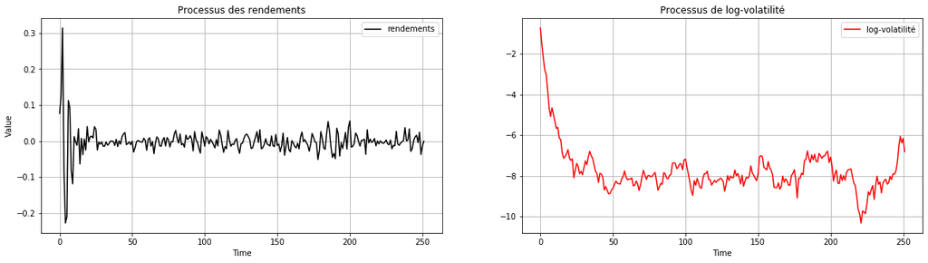

```python
fig, (ax1, ax2) = plt.subplots(1,2, sharey=False, sharex = True, figsize = (20,5))

ax1.plot(rt, color = 'black', label = 'rendements')
ax2.plot(xt, color = 'red', label = 'log-volatilité')
ax1.legend()
ax2.legend()
ax1.set_xlabel('Time')
ax2.set_xlabel('Time')
ax1.set_ylabel('Value')
leg = plt.legend()
ax2.set_title('Processus de log-volatilité')
ax1.set_title('Processus des rendements')
plt.show()
```

Finalement, en traçant les deux trajectoires sur un même graphique, nous obtenons :

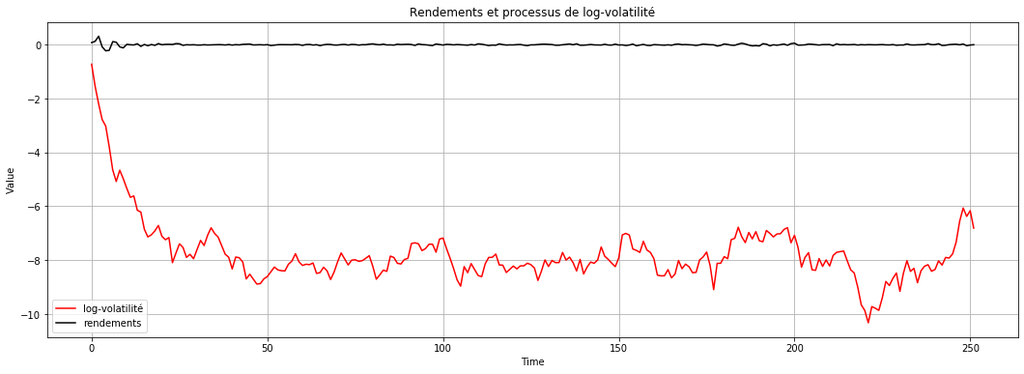

```python
fig, ax = plt.subplots()

plt.plot(xt, color = 'red', label = 'log-volatilité')
plt.plot(rt, color = 'black', label = 'rendements')

plt.xlabel('Time')
plt.ylabel('Value')
leg = ax.legend()
plt.title('Rendements et processus de log-volatilité')
plt.show()
```

Notons que nous avons pris une valeur initiale très élevée pour la log-volatilité, cela est visible sur les deux graphiques. Avec ce choix concernant les paramètres, la log-volatilité va progressivement se stabiliser autour d'une valeur proche de -8, cela est d'autant plus visible lorsque l'on choisit un n plus grand (10000 par exemple).

### Simplification du modèle de Taylor en modèle linéaire log-SV

Il est par ailleurs possible et avisé de simplifier le modèle initial en un modèle linéaire afin de pouvoir estimer la trajectoire de la log-volatilité à partir du processus des rendements observés, notamment via un filtre de Kalman.

Plus précisément, le processus des rendements $r_t$ peut se réécrire de la manière suivante, en l'élevant au carré puis en passant au logarithme :

$$ r_{t} = exp(\frac{x_{t}}{2})\xi_{t} $$

devient :

$$ r_{t}^2 = exp(x_{t})\xi^2_{t} $$

et en passant au logarithme :

$$ ln(r_{t}^2) = x_t + ln(\xi^2_{t}) $$

Ce qui donne finalement en soustrayant l'espérance du nouveau processus $ln(\xi^2_{t})$, sachant les paramètres $\theta_{0}$ aux deux membres de l'égalité :

$$ ln(r_{t}^2) - \mathbb{E}_{\theta_{0}}[ln(\xi^2_{t})] = x_t + ln(\xi^2_{t}) - \mathbb{E}_{\theta_{0}}[ln(\xi^2_{t})] $$

Ainsi, en introduisant les processus :

- $y_t = ln(r_{t}^2) - \mathbb{E}_{\theta_{0}}[ln(\xi^2_{t})]$
- $\epsilon_t = ln(\xi^2_{t}) - \mathbb{E}_{\theta_{0}}[ln(\xi^2_{t})]$

Il est possible de réécrire le modèle de volatilité de Taylor comme un modèle linéarisé:

$$\left\{\begin{matrix} y_{t} = x_t + \epsilon_t\\ x_{t} = \mu + \phi x_{t-1} + \sigma_{\eta}\eta_{t} \end{matrix} \right. $$

Ce modèle est appelé modèle log-linéarisé de Taylor.

Sachant que $\xi_{t} \sim \mathcal{N}(0,1)$, alors son processus au carré suit une loi de $\chi^2$ à un degré de liberté : $\xi^2_{t} \sim \chi^2(1)$.

Cela permet de dire que le nouveau processus $ln(\xi^2_{t})$ suit une loi dite de $log(\chi^2)$ à un degré de liberté.

Il est supposé par la suite que la moyenne et la variance de ce processus sont connus : $\mathbb{E}_{\theta_{0}}[ln(\xi^2_{t})] = -1.27$ et $\mathbb{V}_{\theta_{0}}[ln(\xi^2_{t})] = \pi^2/2$.

### Visualisation de la densité de la loi $log(\chi^2)$ avec celle de la loi Normale

Sachant que la densité d'une loi $log(\chi^2)$ à un degré de liberté s'exprime comme suit :

$$ f_{log(\chi^2)}(y) = \frac{1}{\sqrt{2\pi}}exp(\frac{y}{2} - \frac{e^y}{2}) $$

Celle ci est implémentée de cette manière :

```python
def dens_log_chisq(y):
    return (1/np.sqrt(2*pi))*np.exp((y/2)-(np.exp(y)/2))
```

```python
%%capture --no-stdout
y_time = np.linspace(start = -100, stop = 100, num = 1e3)
log_chisq = dens_log_chisq(y_time)
```

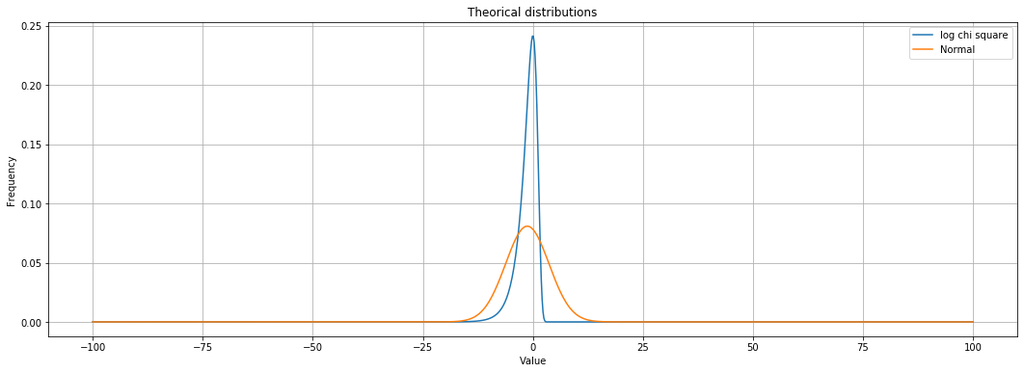

```python
fig, ax = plt.subplots()

plt.plot(y_time, log_chisq, label = 'log chi square')
plt.plot(y_time, st.norm.pdf(y_time, loc = -1.27, scale = (pi**2)/2), label = 'Normal')
plt.xlabel('Value')
plt.ylabel('Frequency')
leg = ax.legend()
plt.title('Theorical distributions')
plt.show()
```

Cependant, ce résultat a permis à Nelson(1988) et Harvey(1994) d'approximer la distribution de la loi de $log(\chi^2)$ par celle une loi normale de moyenne $\psi(1/2) - ln(1/2) \approx -1.27$ avec $\psi$ la fonction digamma et de variance $\pi^2/2$, ce qui permet ainsi de considérer les $\epsilon_t = ln(\xi^2_{t}) - \mathbb{E}_{\theta_{0}}[ln(\xi^2_{t})] $ précédents comme des variables gaussiennes centrées et de variance $\pi^2/2$, et ainsi de pouvoir appliquer un filtre de Kalman traditionnel sur le modèle.

## Estimation du processus de log-volatilité par filtrage de Kalman

Au regard du modèle de Taylor, le but est d'estimer le processus de volatilité $x_t$ à partir de celui des rendements $r_t$ observés, avec adaptation en temps réel de l'information disponible. Avec le modèle log-linéarisé de Taylor établi précédemment à partir du modèle de Taylor initial, l'approche utilisée pour l'estimation du modèle est le filtrage de Kalman :

Plus précisément, un espace d'état général est considéré :

$$ \left\{ \begin{array}{ll} y_t =h_{\theta}(d_t, x_t, \epsilon_t) \\ x_t = f_{\theta}(u_t, x_{t-1}, \eta_t) \end{array} \right. $$

avec :

- $(y_t)_{t \geq 0}$ qui est l'état observable, indépendant conditionnellement à $x_t$, c'est à dire $p_{\theta}(y_t|y_{1:t-1}, x_{0:t}) = p_{\theta}(y_t|x_{t})$.
- $(x_t)_{t \geq 0}$ qui est l'état latent, inobservable, et qui est une Chaîne de Markov de distribution initiale $p_{\theta}(x_0)$ et de matrice de transition $p_{\theta}(x_t|x_{t-1})$.
- La seconde équation est appelée équation d'état, tandis que la première est appelée équation d'observation.
- Les bruits blancs $\epsilon_t$ et $\eta_t$ sont i.i.d., centrés, et de variance respective $R$ et $Q$.
- Les fonctions $h_{\theta}$ et $f_{\theta}$ sont supposées connus.
- Les processus $d_t$ et $u_t$ sont déterministes.

Ainsi, l'objectif de l'utilisation des filtres est d'estimer la distribution à postériori $p_{\theta}(x_{0:t}|y_{1:t})$ ou la distribution marginale $p_{\theta}(x_{t}|y_{1:t})$.

Afin de pouvoir appliquer le filtre de Kalman, les hypothèses suivantes doivent être respectées :

- Les fonctions $h_{\theta}$ et $f_{\theta}$ sont supposées connus, et doivent être linéaire respectivement par rapport à $x_{t-1}$ et $\eta_t$, puis par rapport à $y_{t-1}$ et $\epsilon_t$.
- Les bruits blancs $\epsilon_t$ et $\eta_t$ sont gaussiens centrés réduits, de variance respective $\sigma_{\epsilon} = R$ et $\sigma_{\eta} = Q$ connus.
- L'état initial $x_0$ suit une loi $\mathcal(\hat{x_0}, P_0)$ avec $\hat{x_0}$ et $P_0$ connus

Cela permet ainsi de définir l'espace d'état de Kalman :

$$ \left\{ \begin{array}{ll} y_t = d_t(\theta) + C_{\theta} x_t + \epsilon_t \\ x_t = \mu_t(\theta) + A_{\theta} x_t + \eta_t \end{array} \right. $$

Sachant que les bruits blancs $\epsilon_t$ et $\eta_t$ sont gaussiens, ainsi donc que $x_t$, alors sa distribution marginale $p_{\theta}(x_{t}|y_{1:t})$ est complètement déterminée par sa moyenne et sa variance : $\hat{x}_t = \mathbb{E}_{\theta}[x_{t}|y_{1:t}]$ et $P_t = \mathbb{V}_{\theta}[x_{t}|y_{1:t}] = \mathbb{E}_{\theta}[(x_{t} - \hat{x}_t)'(x_{t} - \hat{x}_t)|y_{1:t}]$. Ainsi, estimer cette distribution revient à estimer ces deux quantités.

De ce fait, l'estimation de l'ensemble du signal $x_{0:t}$ s'effectue donc comme suit :

- Estimation de la moyenne et la variance de $x_t$ par rapport aux observations passés $y_{1:t-1}$, qui sont : . $\hat{x}_t^{-} = \mathbb{E}_{\theta}[x_{t}|y_{1:t-1}] = \mu_t(\theta) + A_{\theta} \hat{x}_{t-1}$ et $P_t^{-} = \mathbb{E}_{\theta}[(x_{t} - \hat{x}_t)'(x_{t} - \hat{x}_t)|y_{1:t-1}] = A_{\theta}^2 P_{t-1} + Q$, ce qui permet d'estimer la distribution : $p_{\theta}(x_t|y_{1:t-1})$. Il s'agit de l'étape de prédiction.
- La seconde étape est la mise à jour, où la nouvelle observation $y_t$ est utilisée pour corriger la prédiction précédente $\hat{x}_t^{-}$, et obtenir les nouvelles estimations $\hat{x}_t$ et $P_t$, ce qui permet d'établir la distribution $p_{\theta}(x_{t}|y_{1:t}) = \mathcal{N}(\hat{x}_t,P_t)$.

La mise à jour se fait par minimisation des moindres carrés, ou plus précisément par calcul de la quantité $K_t = min P_t^{-}$ c'est à dire $K_t = (P_t^{-})^T C_{\theta}(C_{\theta} (P_t^{-})^T C_{\theta} + R)^{-1}$ dite la matrice de Kalman, ce qui permet d'obtenir comme suit :

$$ \hat{x}_t = \hat{x}_t^{-} + K_t(y_t - \hat{y}^{-}_t) $$

Ainsi que :

$$ P_t = (I_d - K_t C_{\theta}) P_t^{-} $$

En reprenant le modèle linéarisé de Taylor

$$ \left\{ \begin{array}{ll} y_{t} = x_t + \epsilon_t\\ x_{t} = \mu + \phi x_{t-1} + \sigma_{\eta}\eta_{t} \end{array} \right. $$

qui implique que :

$$ \left\{ \begin{array}{ll} d_t(\theta) = 0,\ C_{\theta} = 1,\ \sigma_{\eta} = \mathbb{V}[log(\chi^2(1)]\\ \mu_{t}(\theta) = \mu, \ A_{\theta} = \phi, \sigma_{\epsilon} = \sigma^2 \end{array} \right. $$

Le filtre de Kalman s'effectue donc comme suit, notamment grâce à l'approximation effectuée par Nelson et Harvey concernant la distribution du bruit blanc $\epsilon_t$, initialement de loi $log(\chi^2(1))$, en une loi normale de moyenne $\psi(1/2) - log(1/2)$ et de variance $\pi^2/2$, sachant que l'on dispose des observations $y_{1:n}$ :

On échantillonne $x_0 \sim \mathcal{N}(\hat{x}_0, P_0)$, avec $\hat{x}_0 = \frac{\mu}{1-\phi}$ et $P_0 = \frac{\sigma_{\eta}^2}{1- \phi^2}$

Pour $t \geq 1$, l'étape de prédiction donne :

$$ \left\{ \begin{array}{lll} \hat{x}_t^{-} = \mu + \phi \hat{x}_{t-1} \\ \hat{P}_t^{-} = \phi^2 P_{t-1} + \sigma_{\eta} \\ \hat{y}_t^{-} = \hat{x}_t^{-} \end{array} \right. $$

Et concernant la mise à jour grâce à la nouvelle observation $y_t$, et sachant que la matrice de Kalman est égale à $K_t = \frac{P_t^{-}}{P_t^{-} + \sigma^2_{\epsilon}}$:

$$ \left\{ \begin{array}{lll} K_t = \frac{P_t^{-}}{P_t^{-} + \sigma^2_{\epsilon}} \\ \hat{x}_t = \hat{x}_t^{-} + K_t(y_t - \hat{y}_t^{-}) \\ \hat{P}_t = (1 - K_t) P^{-}_t \end{array} \right. $$

En supposant les paramètres $\theta_{0} = (\mu, \phi, \sigma_{\eta}^{2})$ connus, l'implémentation du filtre de Kalman pour le modèle linéarisé de Taylor s'effectue comme suit :

```python
def Kalman(Theta0, y):
    #Paramètres de Theta0 :
    mu, phi, sigma_eta_2 = Theta0[0], Theta0[1], Theta0[2]
    #On ajoute les paramètres de la loi approximée gaussienne pour les résidus :
    m = -1.27
    sigma_epsilon_2 = np.pi**2/2
    #On simule x0 (que l'on stocke dans le vecteur des x)
    P0 = sigma_eta_2/(1-phi**2)
    x0 = st.norm.rvs(loc=mu/(1-phi), scale=P0, size=1)
    #On effectue la 1re itération, d'abord l'étape prédiction
    xt = mu + phi*x0
    Pt = phi**2*P0+sigma_eta_2
    yt = xt
    #étape mise à jour
    Kt = Pt/(Pt+sigma_epsilon_2)
    x = [xt + Kt*(y[0]-yt)]
    P = (1 - Kt)*Pt
    #Puis on boucle :
    for i in range(1,len(y)):
        #étape prédiction
        xt = mu + phi*x[i-1]
        Pt = phi**2*P+sigma_eta_2
        yt = xt
        #étape mise à jour
        Kt = Pt/(Pt+sigma_epsilon_2)
        x.append(xt + Kt*(y[i]-yt))
        P = (1 - Kt)*Pt
    return(x)
```

Ce qui permet de l'appliquer sur le modèle avec les paramètres $\theta_{0} = (\mu, \phi, \sigma_{\eta}^{2}) = (-0.8, 0.9, 0.09)$ précédemment spécifiés, tout en récupérant les valeurs de $y_{t}$ à partir de la formule : $y_{t} = log(r_{t}^{2}) - E_{\theta_{0}}[log(\xi_{t}^{2})]$, avec $E_{\theta_{0}}[log(\xi_{t}^{2})] = m = -1.27$ :

```python
#On récupère nos y à partir des rendements issus de notre simulation :
yt = [np.log(i**2) + 1.27 for i in rt]
#Paramètres
Theta0 = [-0.8,0.9,0.09]
#On applique le filtre pour récupérer les x
xt_hat = Kalman(Theta0, yt)
```

Il est ainsi possible de visualiser la log-volatilité $\hat{x}_t$ du modèle linéaire de Taylor estimée par le filtre de Kalman ainsi que la log-volatilité observée après simulation du modèle de Taylor :

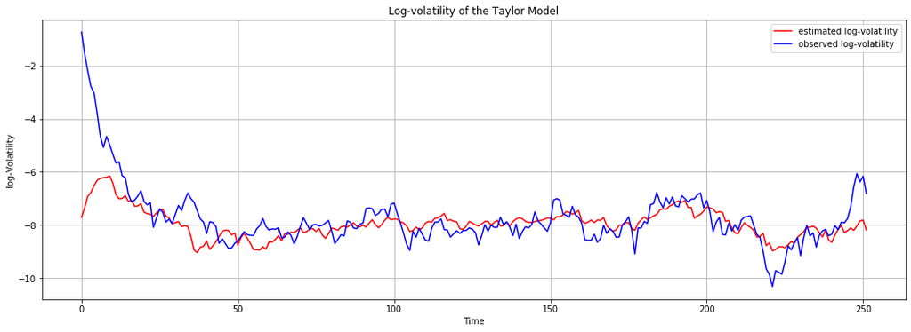

```python
fig, ax = plt.subplots()

# Visualisation et comparaison des log-volatilités observés et estimé par le filtre de Kalman
plt.plot(xt_hat, color="red", label = 'estimated log-volatility')
plt.plot(xt, color="blue", label = 'observed log-volatility')
plt.xlabel('Time')
plt.ylabel('log-Volatility')
leg = ax.legend()
plt.title('Log-volatility of the Taylor Model')
plt.show()
```

Nous pouvons ainsi constater que le filtre de Kalman est capable de répliquer avec assez de précision précision la log-volatilité du modèle de Taylor selon les paramètre connus qui sont : $\theta_{0} = (\mu, \phi, \sigma_{\eta}^{2}) = (-0.8, 0.9, 0.09)$, puisque la trajectoire des log-volatilités observés et estimés semblent similaires. Cependant, il est par ailleurs possible de constater que le filtre ne réagit que faiblement aux variations de volatilité.

## Estimation des paramètres $\theta_0$ par quasi - maximum de vraisemblance

Il est convenu dans le cas présent de relâcher l'hypothèse $\theta_0$ connu. L'enjeu est donc d'estimer en même temps le signal $x_t$ inobservable par Filtre de Kalman, ainsi que les paramètres qui le sont via une méthode dite de quasi-maximum de vraisemblance, moins efficace que la méthode de maximum de vraisemblance traditionnelle, mais plus robuste dans le cas de figure présent, puisque la loi des résidus $\epsilon_t$ ne suivent pas une loi normale mais une loi $log(\chi^2)$ à un degré de liberté.

Concernant ce dernier point, il s'agit plus précisément, à partir des observations $y_1,...,y_n$, de maximiser la quantité suivante :

$$ l(\theta) = logL_{\theta}(y_{1:n}) = -\frac{n}{2}log(2\pi) - \frac{1}{2} \sum_{i=0}^n logF_t - \frac{1}{2} \sum_{i=0}^n \frac{\nu_t^2}{F_t} $$

où $\nu_t$ et $F_t$ sont donnés par :

- $\nu_t = (y_t - \hat{y}_t^{-})$
- $F_t = \mathbb{V}_{\theta}[\nu_t]= P_t^{-} + \sigma_{\epsilon}^2$

avec $\hat{y}_t^{-} = \mathbb{E}_{\theta}[y_t|y_{1:t-1}]$ et $P_t^{-} = \mathbb{V}_{\theta}[(x_t - \hat{x}_t^{-})^2]$ qui sont estimés par le filtre de Kalman.

Cela permet de calculer l'estimateur des paramètres :

$$ \hat{\theta}_{n} = argmax_{\theta \in \Theta} l(\theta) $$

Ainsi, l'opposé de la log-vraisemblance pour le modèle linéaire de Taylor devant être minimisé peut être implémenté comme suit :

```python
#D'abord, on implémente une fonction qui calcule la log-vraisemblance négative (que l'on minimsera avec minimize) :
def neg_LL(Theta0, y):
    #taille des données :
    n = len(y)
    #Paramètres de Theta0 :
    mu, phi, sigma_eta_2 = Theta0[0], Theta0[1], Theta0[2]
    #On a nécessairement phi < 1, sinon x0 est mal défini, nous forçons donc cette règle, sinon la fonction minimize
    #ne va pas fonctionner.
    if phi > 1:
        phi = 2 - phi
    #On ajoute les paramètres de la loi approximée gaussienne pour les résidus :
    m = -1.27
    sigma_epsilon_2 = np.pi**2/2
    #On simule x0 (que l'on stocke dans le vecteur des x)
    P0 = sigma_eta_2/(1-phi**2)
    x0 = st.norm.rvs(loc=mu/(1-phi), scale=P0, size=1)
    #On effectue la 1re itération, d'abord l'étape prédiction
    xt = mu + phi*x0
    Pt = phi**2*P0+sigma_eta_2
    yt = xt
    #étape mise à jour
    Kt = Pt/(Pt+sigma_epsilon_2)
    x = [xt + Kt*(y[0]-yt)]
    P = (1 - Kt)*Pt
    #On initialise les vecteurs utiles pour le calcul de la vraisemblance :
    nut = [y[0]-yt]
    Ft = [Pt + sigma_epsilon_2]
    #Puis on boucle :
    for i in range(1,len(y)):
        #étape prédiction
        xt = mu + phi*x[i-1]
        Pt = phi**2*P+sigma_eta_2
        yt = xt
        #étape mise à jour
        Kt = Pt/(Pt+sigma_epsilon_2)
        x.append(xt + Kt*(y[i]-yt))
        P = (1 - Kt)*Pt
        #Ajout des valeurs aux vecteurs utiles pour le calcul de la vraisemblance :
        nut.append(y[i]-yt)
        Ft.append(Pt + sigma_epsilon_2)
    #Puis on renvoie la vraisemblance négative
    LL = - n/2*np.log(2*np.pi)
    for i in range(len(Ft)):
        LL -= 0.5*np.log(Ft[i]) + 0.5*nut[i]**2/Ft[i]
    return(-LL)
```

Par la suite, L'implémentation de la fonction permettant de minimiser cette fonction selon des paramètres initiaux peut être effectuée :

```python
from scipy.optimize import minimize,Bounds

#Puis, on crée la fonction qui renverra Theta0, minimisant la log-vraisemblance négative :
def Theta_estim(y, params_init):
    #lambda-fonction avec y comme paramètre :
    n_LL = lambda Theta: neg_LL(Theta, y)
    #On minimise notre lambda fonction avec minimize :
    return(minimize(n_LL, x0 = params_init, method='Nelder-Mead'))
```

Ainsi, à partir des observations $y_t$ obtenus précédemment grâce à la simulation des rendements $r_t$, il est possible d'estimer les paramètres du modèle de Taylor par Quasi-maximum de vraisemblance :

```python
#On initialise arbitrairement :
params_init = [-0.5, 0.5, 0.05]
#Puis on estime Theta0 :
Theta_est = Theta_estim(yt, params_init)['x']
print(Theta_est)
```

```
[-0.71204407  0.91003222  0.04668188]
```

Ainsi, l'application de la méthode de quasi-maximum de vraisemblance permet d'obtenir l'estimation des paramètres $\theta_0$, qui sont égaux à : $\hat{\theta}_{0} = (\hat{\mu}, \hat{\phi}, \hat{\sigma}_{\eta}^{2}) = (-0.72, 0.9, 0.047)$.

Il convient par la suite d'appliquer le filtre de Kalman pour modéliser la trajectoire de la log_volatilité $x_t$ en fonction des paramètres nouvellement estimés $\hat{\theta}_{0}$ et de la comparer non seulement avec la log-volatilité observée, mais aussi avec celle estimée avec les paramètres $\theta_0$ fixés initialement à $(-0.8, 0.9, 0.09)$, qui sont les vrais paramètres du modèle puisqu'ils ont servis à la simulation des données :

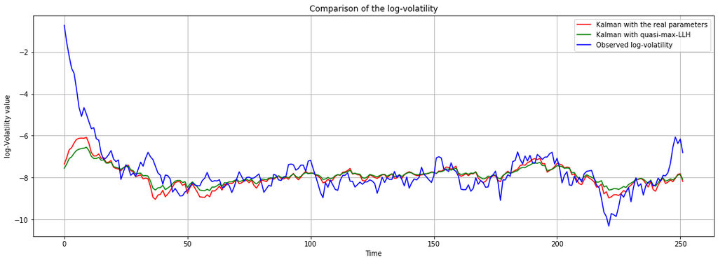

```python
fig, ax = plt.subplots()

#On applique le filtre pour récupérer les xt, avec les theta0 fixés au départ :
xt_hat_init = Kalman(Theta0, yt)
plt.plot(xt_hat_init, color="red", label = 'Kalman with the real parameters')
#On applique le filtre pour récupérer les xt, avec le theta0 estimé par quasi maximum de vraisemblance :
xt_hat_estim = Kalman(Theta_est, yt)
plt.plot(xt_hat_estim, color="green", label="Kalman with quasi-max-LLH")
#On compare nos x empiriques avec les xt théoriques :
plt.plot(xt, color="blue", label="Observed log-volatility")

# Log volatility
plt.xlabel('Time')
plt.ylabel('log-Volatility value')
leg = ax.legend()
plt.title('Comparison of the log-volatility')
plt.show()
```

Il est possible de constater de manière non surprenante que le Filtre de Kalman appliqué avec les vrais paramètres $\theta_{0}$ permet d'obtenir de meilleures volatilités qu'avec l'estimateur des paramètres $\hat{\theta}_{0}$. Néanmoins, la différence est moindre et les résultats obtenus à partir de l'estimateur $\hat{\theta}_{0}$ sont cohérents et exploitables.

## Estimation du modèle non linéaire SV de Taylor par filtrage particulaire

Dans la partie précédente, il a fallu transformer le modèle de Taylor initial en un modèle linéaire afin de pouvoir y appliquer le filtre de Kalman traditionnel pour en déduire le signal $x_{0:t}$ de log-volatilité. Dans ce cas présent, il a été décidé de travailler directement sur le modèle initial c'est à dire non linéaire de Taylor :

$$ \left\{ \begin{array}{ll} r_{t} = exp(\frac{x_{t}}{2})\xi_{t}\\ x_{t} = \mu + \phi x_{t-1} + \sigma_{\eta}\eta_{t} \end{array} \right. $$

Sachant que le modèle n'est pas linéaire, il n'est plus possible d'appliquer le filtre de Kalman traditionnel. Il est donc nécessaire de procéder à un autre type de filtrage dit particulaire ou de Monte Carlo séquentielle, permettant d'estimer la densité filtrée $p_{\theta}(x_{0:t}|y_{1:t})$.

Afin d'estimer cette quantité, une approche intuitive aurait été de calculer la valeur de $I(h) = \mathbb{E}_{\theta}[g(x_{0:t})|y_{1:t}]$ par simulation classique de Monte Carlo donnant une estimation $\hat{I(h)} = \frac{1}{M} = \sum_{i=0}^M g(x^i_{0:t})$.

Cependant, cette quantité est égale $\int_{\chi}g(x_{0:n})p_{\theta}(x_{0:t}|y_{1:t})dx_{0:n}$, ce qui rend la simulation impossible puisque le but est justement d'estimer la probabilité à postériori $p_{\theta}(x_{0:t}|y_{1:t})$, et quand bien même la fonction de densité est connue, la simulation ne peut être effectuée du fait de sa difficulté.

Il convient ainsi de considérer une densité alternative de $x_{0:t}$ conditionnellement aux observations $y_{1:t}$ :$q_{\theta}(x_{0:t}|y_{1:t})$, dite densité d'importance, et permettant de réécrire l'intégrale $I(g) de la manière suivante :

$$ I(g) = \frac{\int_{\chi} g(x_{0:t}) w_{\theta}(x_{0:t})q_{\theta}(x_{0:t}|y_{1:t}) dx_{0:t}}{\int_{\chi} w_{\theta}(x_{0:n})q_{\theta}(x_{0:t}|y_{1:t}) dx_{0:t}} $$

avec les poids $w_{\theta}(x_{0:t})$ exprimés de la manière suivante :

$$ w_{\theta}(x_{0:t}) \propto \frac{p_{\theta}(x_{0:t}|y_{1:t})}{q_{\theta}(x_{0:t}|y_{1:t})} $$

Cela permet d'estimer $I(g)$ d'une nouvelle manière :

$$ \hat{I}^M(g) = \sum_{i=0}^M \hat{w}_{\theta}(x^i_{0:t}) g(x^i_{0:t}) $$

où :

$$ \hat{w}_{\theta}(x_{0:t}) = \frac{w_{\theta}(x^i_{0:t})}{\sum_{j=0}^M w_{\theta}(x^j_{0:t})} $$

Cela permet ainsi d'obtenir une estimation des distributions voulus de $x_t$ et $x_{0:t}$ conditionnellement aux observations $y_{1:t}$ :

$$ p^M_{\theta}(x_{0:t}|y_{1:t}) = \sum_{i=1}^M \hat{w}_{\theta}(x^i_{0:t}) \delta_{x^i_{0:n}}(dx^i_{0:t}) $$

et

$$ p^M_{\theta}(x_t|y_{1:t}) = \sum_{i=1}^M \hat{w}_{\theta}(x^i_{0:t}) \delta_{x^i_n}(dx^i_t) $$

Cependant, la simulation selon cette nouvelle expression est impossible à réaliser de manière directe en raison de la forte dimension du problème. Il convient ainsi de simuler de manière séquentielle.

Sachant donc que grâce au caractère Markovien de $x_t$, de l'indépendance des $y_t$ conditionnellement à $x_t$ qu'il est possible d'écrire :

$$ q_{\theta}(x_{0:t}|y_{1:t}) = q_{\theta}(x_{0:t-1}|y_{1:t-1})*q_{\theta}(x_t|x_{0:t-1}, y_{1:t}) $$

c'est à dire par récurrence :

$$ q_{\theta}(x_{0:t}|y_{1:t}) = q(x_0)\prod_{t=0}^n q_{\theta}(x_t|x_{0:t-1}, y_{1:t}) $$

Les poids peuvent aussi s'écrire de manière récursive, grâce au théorème de Bayes, et pour tout $t \in [|0,n|]$:

$$ w_{\theta}(x_{0:t}) \propto w_{\theta}(x_{0:t-1}) \frac{p_{\theta}(y_t|x_t)p_{\theta}(x_t|x_t-1)}{q_{\theta}(x_t|x_{0:t-1}, y_{1:t})} $$

Cependant, la simulation récursive soulève un autre problème qui est la dégénérescence des poids, c'est à dire l'augmentation progressive dans le temps de la variance de ceux-ci. Ce problème peut être résolu grâce à la simulation d'un très grand nombre de particules, mais au prix d'un temps de calcul fortement conséquent.

Ainsi, il existe une autre solution serait d'introduire une étape de rééchantillonnage (Bootstrap).

Ainsi, au lieu de considérer les poids $w_{\theta}(x_{0:t})$, il sera question d'une quantité $M_t^i$ qui est le nombre de particules 'filles' nouvellement généré par la particule "mère" après rééchantillonnage. Ce rééchantillonnage permettant de choisir $M_t^i$ peut se faire de deux manières : multinomiale ou résiduelle.

Ce faisant, la distribution de $x_{0:t}$ devient :

$$ p_{\theta}^M(x_{0:t}|y_{1:t}) = \frac{1}{M} \sum_{i=1}^M M_t^i \delta_{x^i_{0:t}}(dx^i_{0:t}) $$

La somme des $M_t^i$ est donc égale à $M$ et si $M_t^i=0$ alors la particule $x^i_t$ n'existe plus. Une fois le rééchantillonnage effectué, le poids de tous les particules $x^i_t$ est réinitialisé à $1/M$.

En cas de rééchantillonnage, les poids $w_{\theta}(x_{0:t})$ ne sont plus proportionnels à $w_{\theta}(x_{0:t-1}) \frac{p_{\theta}(y_t|x_t)p_{\theta}(x_t|x_t-1)}{q_{\theta}(x_t|x_{0:n-1}, y_{1:n})}$, mais plutôt à $\frac{p_{\theta}(y_t|x_t)p_{\theta}(x_t|x_t-1)}{q_{\theta}(x_t|x_{0:n-1}, y_{1:n})}$, tout simplement car suite au rééchantillonnage, le poids de toutes les particules : $w_{\theta}(x^i_{0:t})$ est réinitialisé à $1/M$.

Une autre approche concernerait le choix de la distribution $q_{\theta}(x_{0:n}|y_{1:n})$ est déterminante pour la suite, sachant qu'elle doit être choisie de manière à minimiser la variance des poids $w_{\theta}(x_{0:n})$ conditionnellement à $x_{0:n-1}$ et $y_{1:n}$.

Une telle distribution est égale à :

$$ q^{optimal}_{\theta}(x_t|x_{0:t-1},y_{1:t}) = p_{\theta}(x_t|x_{t-1},y_t) $$

De plus il est bien plus optimal de simuler la densité de transition $p_{\theta}(x_n|x_{n-1})$ plutôt que la densité $p_{\theta}(x_n|x_{n-1},y_n)$.

Cela permet ainsi après calculs de redéfinir les poids :

$$ w_{\theta}(x_{0:t}) \propto w_{\theta}(x_{0:t-1}) p_{\theta}(y_t|x_{t-1}) $$

C'est à dire en cas de rééchantillonnage :

$$ w_{\theta}(x_{0:t}) \propto p_{\theta}(y_t|x_{t-1}) $$

L'expression de ce poids est la composante principale de l'algorithme du filtre à particule dit Boostrap, et dont la procédure est la suivante :

Pour $t=0$ et $i = 1...M$ :

- Générer $x^i_0$ selon la densité $p_{\theta}(x_0)$ selon les poids associés $w_{\theta}(x^i_{0:t}) =\frac{1}{M}$

fin pour

Pour $t=1...n$ :

- Pour $i = 1...M$:
  - Générer $x^i_t \sim p_{\theta}(x_t|x^i_{t-1})$. Poser $x^i_{0:t} = (x^i_{0:t-1}, x^i_t)$
  - Mettre à jour les poids : $w_{\theta}(x^i_{0:t}) = p_{\theta}(y_i|x^i_{i-1})$
  - Normaliser les poids : $\tilde{w}_{\theta}(x^i_{0:t})$
  - Etape de rééchantillonnage : rééchantillonner $x^i_t$
  - Réinitialiser les poids : $\tilde{w}_{\theta}(x^i_{0:t}) = 1/M$

    fin pour

finpour

Cet algorithme sera utilisé pour estimer directement le modèle de Taylor sous sa forme non linéaire et ainsi estimer la trajectoire de la log-volatilité $x_t$

L'algorithme de filtrage particulaire Bootstrap est implémenté comme suit :

```python
def fast_bootsrap_filter(yt, M, *params):
    mu, phi, sig = params
    n = len(yt)

    x0_vec = np.random.normal(size = M)
    fun = lambda x:st.norm.pdf(x)
    w = np.array(list((map(fun, x0_vec))))
    w = w/np.sum(w)

    sets = np.zeros((n+1, M))
    sets[0,:] = np.random.normal(size = M)
    sample_index = [i for i in range(M)]
    vol_traject = np.zeros((n,M))

    for t in tq(range(1, n+1)):
        loc = mu+phi*sets[t-1, :]
        scale = sig
        sets[t, :] = np.random.normal(loc = loc, scale = sig)
        w = st.norm.pdf(yt[t-1], loc = 0, scale = np.exp(sets[t,:]/2))
        w /= np.sum(w)

        sampled_id = np.random.choice(sample_index, size = M, replace = True, p = w)
        sets[:, sample_index] = sets[:, sampled_id]

    return sets
```

```python
params = (mu, phi, sig)

vol = fast_bootsrap_filter(rt, 10000, *params)
```

La trajectoire de la log-volatilité ayant pu être estimée à chaque instant $t$ grâce au filtre particulaire Bootstrap, une certaine trajectoire de la log-volatilité $x^i_{0:n}$, disons la 30eme, sa trajectoie moyenne, minimale, et maximale issue du filtrage particulaire Bootstrap peuvent être tracées afin d'être comparées avec celle observée avec les données simulées :

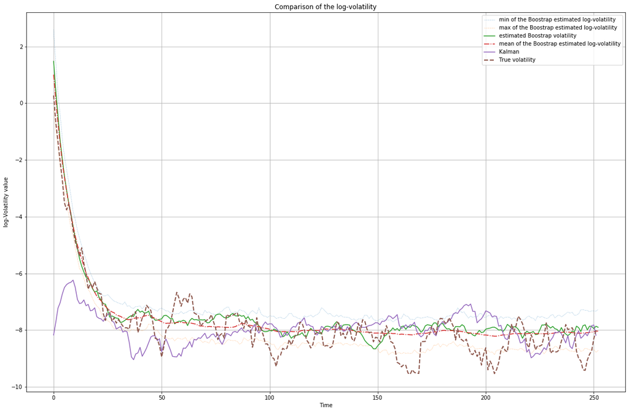

```python
xt_hat_init = Kalman(Theta0, yt)

plt.figure(figsize=(20,13))
plt.plot(vol.max(axis = 1), label = 'min of the Boostrap estimated log-volatility', ls = ':', lw = 0.5)
plt.plot(vol.min(axis = 1), label = 'max of the Boostrap estimated log-volatility', ls = ":", lw = 0.5)
plt.plot(vol[:,30], label = 'estimated Boostrap volatility')
plt.plot(np.mean(vol, axis = 1), label = 'mean of the Boostrap estimated log-volatility', ls = '-.')
plt.plot(xtlabel = 'observed log-volatility')
plt.plot(xt_hat_init, label = 'Kalman')
plt.plot(xt, label = 'True volatility', ls = '--', lw = 2)

plt.xlabel('Time')
plt.ylabel('log-Volatility value')
leg = plt.legend()
plt.title('Comparison of the log-volatility')
plt.show()
```

Ainsi, la précision et la robustesse de l'estimation de la trajectoire permet de conclure quant à l'efficacité certaine du filtrage particulaire Boostrap sur le modèle de Taylor, qui possède par ailleurs l'avantage d'être directement applicable sur le modèle initial, contrairement au filtre de Kalman qui nécessite une transformation en modèle linéaire, et dont la précision peutêtre remise en cause.

## Application sur données réelles : données du Nasdaq

Dans cette partie, il es convenu d’appliquer un filtre particulaire Bootstrap pour estimer la volatilité des rendements du Nasdaq en supposant que ces derniers sont modélisés par le modèle SV de Taylor.

Pour cela, à partir du package "Quantdl", les données réelles du Nasdaq entre Janvier 2012 et Janvier 2014 sont téléchargées puis les prix d'ouvertures sont visualisés :

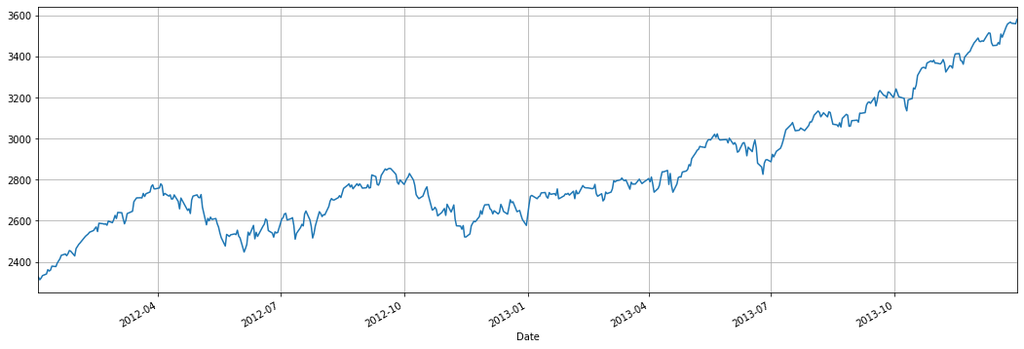

```python
import quandl

data = quandl.get('CHRIS/CME_NQ2', start_date='2012-01-01', end_date='2014-01-01', type = 'zoo')
data["Open"].plot()
plt.show()
```

```python
data.pct_change()+1
```

| Date | Open | High | Low | Last | Change | Settle | Volume | Previous Day Open Interest |
| --- | --- | --- | --- | --- | --- | --- | --- | --- |
| 2012-01-03 | NaN | NaN | NaN | NaN | NaN | NaN | NaN | NaN |
| 2012-01-04 | 0.994517 | 0.996237 | 0.998702 | 0.998707 | NaN | 0.998707 | 0.750000 | 0.971429 |
| 2012-01-05 | 1.003567 | 1.008633 | 1.001624 | 1.008633 | NaN | 1.008633 | 21.666667 | 2.029412 |
| 2012-01-06 | 1.005062 | 1.005242 | 1.007567 | 1.004814 | NaN | 1.004814 | 0.138462 | 1.043478 |
| 2012-01-09 | 1.003537 | 0.998297 | 1.004613 | 0.998509 | NaN | 0.998509 | 0.333333 | 1.000000 |
| ... | ... | ... | ... | ... | ... | ... | ... | ... |
| 2013-12-24 | 1.003667 | 1.000000 | 1.003385 | 1.001405 | NaN | 1.001405 | 0.166667 | 0.975000 |
| 2013-12-26 | 1.002459 | 1.004356 | 1.002741 | 1.003368 | NaN | 1.003368 | 6.000000 | 1.000000 |
| 2013-12-27 | 0.998528 | 0.997062 | 0.998248 | 0.996713 | NaN | 0.996713 | 2.500000 | 1.076923 |
| 2013-12-30 | 0.999228 | 0.998807 | 0.997121 | 0.998737 | NaN | 0.998737 | 0.000000 | 1.333333 |
| 2013-12-31 | 1.005971 | 1.007657 | 1.005563 | 1.005128 | NaN | 1.005128 | inf | 1.000000 |

511 rows × 8 columns

De ce fait, il est possible de calculer les rendements $y_t$ de la série, tel que :

$$ y_t = 100 log(\frac{S_t}{S_{t-1}}) $$

où $S_t$ est la valeur de l'actif sous-jacent c'est à dire la série du Nasdaq :

```python
# Calcul des log rendements du Nasdaq
data_log = 100*np.log(data["Last"].pct_change()+1)
data_log
```

```
Date
2012-01-03         NaN
2012-01-04   -0.129408
2012-01-05    0.859573
2012-01-06    0.480283
2012-01-09   -0.149174
                ...
2013-12-24    0.140430
2013-12-26    0.336229
2013-12-27   -0.329213
2013-12-30   -0.126369
2013-12-31    0.511510
Name: Last, Length: 511, dtype: float64
```

Ce qui donne pour la visualisation :

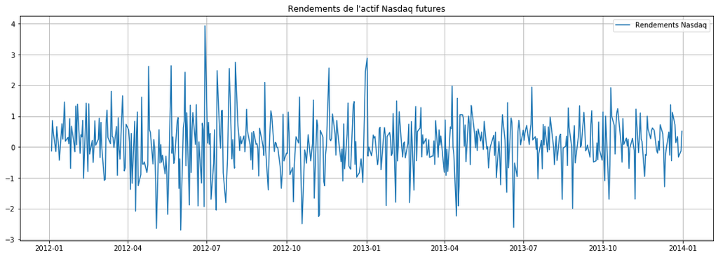

```python
log_rtn = data_log[1:].values
plt.plot(data_log.index[1:], log_rtn, label = 'Rendements Nasdaq')
plt.title("Rendements de l'actif Nasdaq futures")
plt.legend()
plt.show()
```

En supposant connus les paramètres $\theta_{0} = (\mu, \phi, \sigma^2_{\eta})$ du modèle de Taylor servant à modéliser la volatilité des rendements du Nasdaq, égaux à : $\theta_{0} = (-0.1, 0.97, 0.15)$, le filtre particulaire Bootstrap précédemment implémenté sera utilisé pour modéliser cette volatilité, ce qui donne ainsi :

```python
# Application du filtre particulaire sur les données du Nasdaq
params = (-0.1, 0.97, np.sqrt(0.15))
xhat = fast_bootsrap_filter(log_rtn, 200, *params)
```

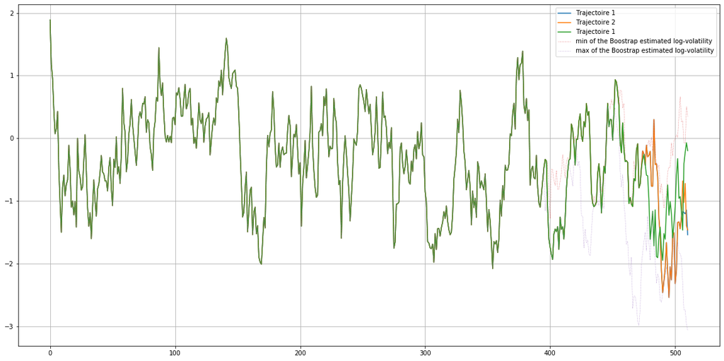

```python
plt.figure(figsize = (20,10))
plt.plot(xhat[:,1], label = 'Trajectoire 1')
plt.plot(xhat[:,2], label = 'Trajectoire 2')
plt.plot(xhat[:,5], label = 'Trajectoire 1')
plt.plot(xhat.max(axis = 1), label = 'min of the Boostrap estimated log-volatility', ls = ':', lw = 0.5)
plt.plot(xhat.min(axis = 1), label = 'max of the Boostrap estimated log-volatility', ls = ":", lw = 0.5)
plt.legend()
plt.show()
```

Ici nous voyons que les trajcetoires sont quasiment les mêmes jusqu'à un certain instant. Cela peut s'expliquer par le fait que certaines observations sont resamplées un grand nombre de fois ce qui au final contribue à l'uniformité des trajectoires. Plus le nombre de particules est grand plus le nombre d'boservation doit l'être également afin d'assurer une stabilité dans les trajectoires au moins jusqu'à un certain instant

La log-volatilité $x_t$ ayant pu être estimée, il est possible de retrouver une estimation du log-rendement $y_t$ de l'indice du Nasdaq via le modèle de Taylor, stipulant que :

$$ y_{t} = exp(\frac{x_{t}}{2})\xi_{t} $$

En choisissant la trajectoire n°1 simulée par filtrage particulaire Bootstrapp : $x^1_{0:n}$ avec $n$ la taille de l'échantillon des rendements du Nasdaq, il est possible d'en estimer les log-rendements de la manière suivante :

```python
mu, phi, sig = params

# Estimation des rendements du Nasdaq avec sa log-volatilité
yt = np.exp(((xhat[:,1]))/2)*np.random.normal(size = xhat.shape[0])
```

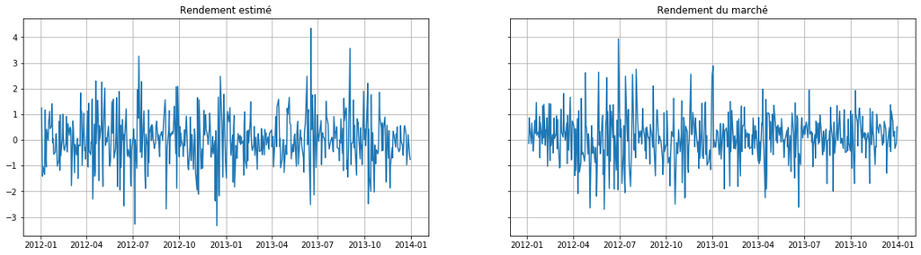

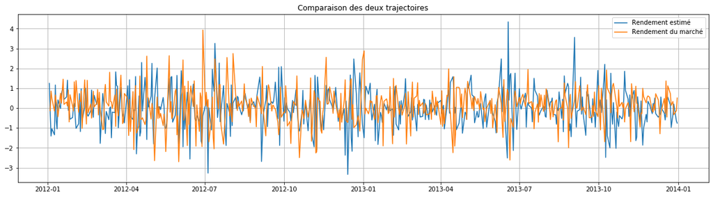

```python
fig, (ax1, ax2) = plt.subplots(1,2, sharey=True, sharex = True, figsize = (20,5))

ax1.plot(data_log.index, yt)
ax1.set_title('Rendement estimé')
ax2.plot(data_log[1:].index, log_rtn)
ax2.set_title('Rendement du marché')
plt.show()

plt.figure(figsize = (20,5) )
plt.plot(data_log.index, yt, label = 'Rendement estimé')
plt.plot(data_log[1:].index, log_rtn, label = 'Rendement du marché')
leg = plt.legend()
plt.title("Comparaison des deux trajectoires")
plt.show()
```

Ainsi, il est possible de constater que le log-rendement estimé via la log-volatilité simulée par filtrage particulaire Boostrap est fortement similaire avec celui calculé avec l'indice du marché du Nasdaq. Ceci est très intéressant car le filtre particulaire ne demande que peu d'hypothèse et d'à priori sur les erreurs.